# AI CA5 Phase1

# Feed Forward Neural Network

**We are going to train a FeedForwardNN model to predict label of a data set of pictures. The labels are cat and horse.**

# Amirmohammad Khosravi Esfezar

# S.N.: 810198386

```python
import pandas as pd
import matplotlib
import statistics
import time
import math
import matplotlib.image as mpimg
import matplotlib.pyplot as plt
import glob
import random
import numpy as np
from PIL import Image
from itertools import chain
from sklearn import preprocessing
from sklearn.preprocessing import MinMaxScaler
from copy import deepcopy
from numpy import array
```

# Part 1: Preprocess

Here we read labels and save them in a data frame called labelsDf. After that we read all images and save each one in a matrix and then we flatten that matrix. We also need to change images colors to black and white, for that we defined a function called rgb2gray.

```python
labelsDf = pd.read_csv('labels.csv')
```

```python
labelsDf
```

|  | id | label |
| --- | --- | --- |
| 0 | 8 | horse |
| 1 | 10 | cat |
| 2 | 12 | horse |
| 3 | 13 | horse |
| 4 | 18 | cat |
| ... | ... | ... |
| 9995 | 49979 | horse |
| 9996 | 49980 | cat |
| 9997 | 49983 | cat |
| 9998 | 49984 | cat |
| 9999 | 49987 | horse |

10000 rows × 2 columns

```python
def rgb2gray(rgb):
    return np.dot(rgb[...,:3], [0.299, 0.587, 0.144])
images = []
for imageName in labelsDf['id'].values:
    image = Image.open('data/' + str(imageName) + '.png')
    imageArr = array(image)
#     image = mpimg.imread('data/' + str(imageName) + '.png')
    images.append(rgb2gray(imageArr))
#     images.append(imageArr)
```

```
[262.65  262.65  262.65  262.65  262.65  262.362 262.65  262.351 262.65
 262.65  262.65  262.65  261.764 262.362 262.362 262.65  262.65  262.65
 262.65  262.351 262.65  262.351 262.351 262.65  262.65  262.65  262.65
 262.65  262.65  262.65  261.62  261.62 ]
```

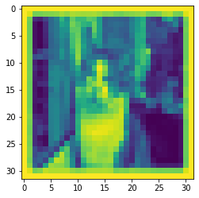

```python
randomNumber = random.randrange(0, len(images))
plt.imshow(images[randomNumber])
print(images[randomNumber][0])
```

Here we flatten each image's matrix and then we convert the matixes into a dataframe called imagesDf.

```python
flatImages = [list(chain.from_iterable(img)) for img in images]
imagesDf = pd.DataFrame(flatImages)
```

```python
print(len(images))
```

```
10000
```

```python
imagesDf
```

|  | 0 | 1 | 2 | 3 | 4 | 5 | 6 | 7 | 8 | 9 | ... | 1014 | 1015 | 1016 | 1017 | 1018 | 1019 | 1020 | 1021 | 1022 | 1023 |
| --- | --- | --- | --- | --- | --- | --- | --- | --- | --- | --- | --- | --- | --- | --- | --- | --- | --- | --- | --- | --- | --- |
| 0 | 34.533 | 35.264 | 42.463 | 77.627 | 78.513 | 44.656 | 43.460 | 58.024 | 71.868 | 79.410 | ... | 122.581 | 115.803 | 139.914 | 144.178 | 134.332 | 153.171 | 156.106 | 130.622 | 128.706 | 126.203 |
| 1 | 127.454 | 105.281 | 95.280 | 102.169 | 103.631 | 140.268 | 176.019 | 175.288 | 146.603 | 95.302 | ... | 109.156 | 110.031 | 111.925 | 114.129 | 116.034 | 118.382 | 120.442 | 123.244 | 122.945 | 123.532 |
| 2 | 151.809 | 176.440 | 173.416 | 177.148 | 206.010 | 218.182 | 202.035 | 139.571 | 123.257 | 137.810 | ... | 159.538 | 155.451 | 127.940 | 77.493 | 71.424 | 125.969 | 137.664 | 135.150 | 135.881 | 138.096 |
| 3 | 210.377 | 207.442 | 207.442 | 208.472 | 208.173 | 208.616 | 209.502 | 209.502 | 209.214 | 209.214 | ... | 155.862 | 151.299 | 148.353 | 149.084 | 148.641 | 147.899 | 141.708 | 141.852 | 142.882 | 140.678 |
| 4 | 107.906 | 138.695 | 148.131 | 133.512 | 84.327 | 57.093 | 49.584 | 53.549 | 53.693 | 54.867 | ... | 72.632 | 72.488 | 67.482 | 64.536 | 66.319 | 60.139 | 56.894 | 50.271 | 49.695 | 52.353 |
| ... | ... | ... | ... | ... | ... | ... | ... | ... | ... | ... | ... | ... | ... | ... | ... | ... | ... | ... | ... | ... | ... |
| 9995 | 166.317 | 84.304 | 106.543 | 109.943 | 106.709 | 106.133 | 110.718 | 121.184 | 128.837 | 133.112 | ... | 245.849 | 245.849 | 245.849 | 245.849 | 245.849 | 245.849 | 245.849 | 243.047 | 233.500 | 261.620 |
| 9996 | 4.120 | 4.120 | 5.150 | 0.000 | 66.794 | 178.177 | 170.635 | 157.223 | 156.359 | 153.413 | ... | 53.083 | 66.196 | 86.508 | 76.496 | 50.259 | 23.280 | 7.365 | 12.803 | 11.330 | 3.090 |
| 9997 | 42.230 | 39.882 | 39.738 | 40.923 | 42.839 | 42.983 | 45.043 | 47.103 | 48.277 | 49.750 | ... | 60.171 | 59.883 | 60.326 | 62.098 | 62.386 | 63.272 | 64.158 | 63.128 | 63.726 | 66.528 |
| 9998 | 32.306 | 32.173 | 30.423 | 31.464 | 33.701 | 37.389 | 38.264 | 42.129 | 89.919 | 151.033 | ... | 189.263 | 124.926 | 150.898 | 183.250 | 223.941 | 230.431 | 221.770 | 231.472 | 239.391 | 223.974 |
| 9999 | 146.584 | 147.470 | 148.356 | 148.356 | 148.799 | 149.242 | 149.829 | 150.416 | 150.416 | 150.560 | ... | 199.221 | 196.718 | 191.269 | 192.742 | 189.054 | 189.940 | 188.456 | 194.957 | 187.149 | 186.263 |

10000 rows × 1024 columns

```python
testTrainRatio = int(0.98 * len(images))
testImages = images[testTrainRatio:]
trainImages = images[:testTrainRatio]
testImagesDf = imagesDf[testTrainRatio:]
trainImagesDf = imagesDf[:testTrainRatio]
testLabels = labelsDf[testTrainRatio:]
trainLabels = labelsDf[:testTrainRatio]
print('All images count : ', len(images))
print('Train images count : ', len(trainImages))
print('Test images count : ', len(testImages))
```

```
All images count :  10000
Train images count :  9800
Test images count :  200
```

Here we show a random image from each class and also tell its label.

```
Minimum pixel number :  0.0
Maximum pixel number :  261.775
Type :  horse
```

[figure not shown]

```python
# For train data
randomNumber = random.randrange(0, len(trainImages))
plt.imshow(trainImages[randomNumber], cmap='gray')
print('Minimum pixel number : ', min(trainImagesDf.iloc[randomNumber]))
print('Maximum pixel number : ', max(trainImagesDf.iloc[randomNumber]))
print('Type : ', trainLabels['label'].values[randomNumber])
```

```
Minimum pixel number :  9.27
Maximum pixel number :  232.336
Type :  horse
```

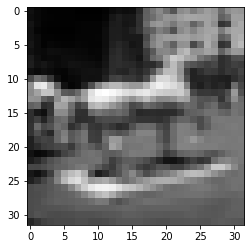

```python
# For test data
randomNumber = random.randrange(0, len(testImages))
plt.imshow(testImages[randomNumber], cmap='gray')
print('Minimum pixel number : ', min(testImagesDf.iloc[randomNumber]))
print('Maximum pixel number : ', max(testImagesDf.iloc[randomNumber]))
print('Type : ', testLabels['label'].values[randomNumber])
```

Here we plot number of horses and cats in each data set (train and test). As we can see they are almost equal in both.

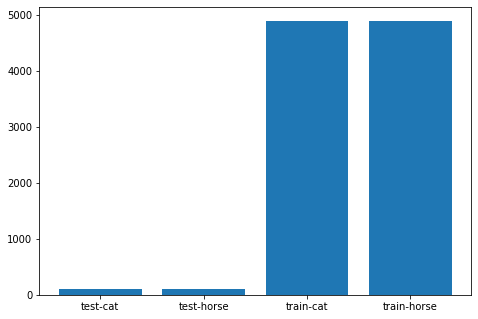

```python
fig = plt.figure()
ax = fig.add_axes([0,0,1,1])
labels = ['test-cat', 'test-horse', 'train-cat', 'train-horse']
counts = [testLabels['label'].value_counts()['cat'],
          testLabels['label'].value_counts()['horse'],
          trainLabels['label'].value_counts()['cat'],
          trainLabels['label'].value_counts()['horse']]
ax.bar(labels,counts)
plt.show()
```

```python
print('Before normalization: (min and max)')
print(min(list(min(trainImagesDf[x]) for x in trainImagesDf.columns)))
print(max(list(max(trainImagesDf[x]) for x in trainImagesDf.columns)))

resultDf = testImagesDf.copy()
for col in testImagesDf.columns:
    minImg = min(testImagesDf[col])
    maxImg = max(testImagesDf[col])
    resultDf[col] = (testImagesDf[col] - minImg) / (maxImg - minImg)
testImagesDf = resultDf

resultDf = trainImagesDf.copy()
for col in trainImagesDf.columns:
    minImg = min(trainImagesDf[col])
    maxImg = max(trainImagesDf[col])
    resultDf[col] = (trainImagesDf[col] - minImg) / (maxImg - minImg)
trainImagesDf = resultDf

print('After normalization: (min and max)')
print(min(list(min(trainImagesDf[x]) for x in trainImagesDf.columns)))
print(max(list(max(trainImagesDf[x]) for x in trainImagesDf.columns)))
```

```
Before normalization: (min and max)
0.0
262.65
After normalization: (min and max)
0.0
1.0
```

```python
trainImagesDf
```

|  | 0 | 1 | 2 | 3 | 4 | 5 | 6 | 7 | 8 | 9 | ... | 1014 | 1015 | 1016 | 1017 | 1018 | 1019 | 1020 | 1021 | 1022 | 1023 |
| --- | --- | --- | --- | --- | --- | --- | --- | --- | --- | --- | --- | --- | --- | --- | --- | --- | --- | --- | --- | --- | --- |
| 0 | 0.131479 | 0.134262 | 0.161671 | 0.295553 | 0.298926 | 0.170021 | 0.165467 | 0.220918 | 0.273626 | 0.302342 | ... | 0.466709 | 0.440902 | 0.532701 | 0.548936 | 0.511449 | 0.583175 | 0.594350 | 0.497323 | 0.490029 | 0.480499 |
| 1 | 0.485262 | 0.400841 | 0.362764 | 0.388993 | 0.394559 | 0.534049 | 0.670166 | 0.667382 | 0.558169 | 0.362848 | ... | 0.415595 | 0.418926 | 0.426137 | 0.434529 | 0.441782 | 0.450721 | 0.458565 | 0.469233 | 0.468094 | 0.470329 |
| 2 | 0.577990 | 0.671769 | 0.660255 | 0.674464 | 0.784352 | 0.830695 | 0.769218 | 0.531395 | 0.469282 | 0.524691 | ... | 0.607417 | 0.591856 | 0.487112 | 0.295043 | 0.271936 | 0.479608 | 0.524135 | 0.514563 | 0.517346 | 0.525780 |
| 3 | 0.800978 | 0.789804 | 0.789804 | 0.793725 | 0.792587 | 0.794274 | 0.797647 | 0.797647 | 0.796551 | 0.796551 | ... | 0.593421 | 0.576048 | 0.564832 | 0.567615 | 0.565928 | 0.563103 | 0.539532 | 0.540080 | 0.544002 | 0.535610 |
| 4 | 0.410836 | 0.528060 | 0.563986 | 0.508327 | 0.321062 | 0.217373 | 0.188784 | 0.203880 | 0.204428 | 0.208898 | ... | 0.276535 | 0.275987 | 0.256927 | 0.245711 | 0.252500 | 0.228970 | 0.216615 | 0.191399 | 0.189206 | 0.199326 |
| ... | ... | ... | ... | ... | ... | ... | ... | ... | ... | ... | ... | ... | ... | ... | ... | ... | ... | ... | ... | ... | ... |
| 9795 | 0.967954 | 0.967954 | 0.976345 | 0.979718 | 0.975797 | 0.991567 | 0.936749 | 0.692515 | 0.926670 | 1.000000 | ... | 0.439676 | 0.430653 | 0.411003 | 0.433984 | 0.435713 | 0.383636 | 0.393166 | 0.426731 | 0.406575 | 0.432930 |
| 9796 | 0.805981 | 0.813234 | 0.840685 | 0.767272 | 0.616859 | 0.713630 | 0.511483 | 0.189115 | 0.249960 | 0.318226 | ... | 0.654555 | 0.639376 | 0.611883 | 0.578824 | 0.556981 | 0.526115 | 0.457678 | 0.406613 | 0.381904 | 0.360019 |
| 9797 | 0.099486 | 0.096703 | 0.100541 | 0.102144 | 0.104927 | 0.102185 | 0.096703 | 0.098389 | 0.099486 | 0.099486 | ... | 0.094974 | 0.093920 | 0.095058 | 0.097293 | 0.095058 | 0.092823 | 0.090630 | 0.089027 | 0.088985 | 0.096155 |
| 9798 | 0.694327 | 0.700525 | 0.728525 | 0.755766 | 0.775290 | 0.783724 | 0.779212 | 0.779044 | 0.756105 | 0.753954 | ... | 0.498671 | 0.489267 | 0.456208 | 0.400632 | 0.378157 | 0.384862 | 0.352309 | 0.352857 | 0.338351 | 0.314822 |
| 9799 | 0.554285 | 0.546990 | 0.549225 | 0.553147 | 0.557617 | 0.573387 | 0.594217 | 0.604885 | 0.613824 | 0.621668 | ... | 0.531810 | 0.541930 | 0.530166 | 0.536870 | 0.552557 | 0.544713 | 0.513341 | 0.510558 | 0.537544 | 0.559387 |

9800 rows × 1024 columns

# Dataloader

```python
class Dataloader:
    '''
    This class prepares the dataset for the neural network.
    '''

    def __init__(self, data, labels, n_classes, batch_size=None, shuffle=False):
        '''
        This is the constructor. It gets dataset information and initializes the
        Dataloader class fields.
            Parameters:
                data: features your dataset in pandas.Dataframe format.
                labels: labels of your dataset in pandas.Dataframe format.
                n_classes: number of classes you have in your dataset.
                batch_size: the number of samples that will be propagated through the network.
                shuffle: boolean value indicating whether or not the dataset should be shuffled
        '''

        assert len(data)==len(labels)
        self.__n_classes = n_classes
        self.__batch_size = batch_size
        self.__shuffle = shuffle
        self.__data = data
        self.__onehot_labels = self.__onehot(labels, self.__n_classes)

    def __onehot(self, labels, n_classes):
        '''
        This private method gets labels and provides one_hot vectors of labels.
        For categorical variables where no such ordinal relationship exists,
        the integer encoding is not enough.
        In this case, a one-hot encoding can be applied to the integer representation.
        This is where the integer encoded variable is removed, and a new binary variable is
        added for each unique integer value.
        example:
            red,    green,    blue
            1,      0,        0
            0,      1,        0
            0,      0,        1
                Parameters:
                        label: lables of your dataset in pandas.Dataframe format.
                        n_classes: number of classes you have in your dataset.

                Returns:
                    onehot_vectors: onehot vectors of the labels
        '''
        # TODO: Implement
        onehot_vectors = []
        for label in labels:
            row = [0] * n_classes
            if label == "horse":
                row[1] = 1
            else:
                row[0] = 1
            onehot_vectors.append(row)
        return onehot_vectors

    def __shuffle_dataset(self):
        '''
        This private method shuffles your dataset.
        It uses data and onehot_labels to shuffle them
        symmetrical.
        '''
        # TODO: Implement
        pass

    def __iter__(self):
        '''
        The __iter__() function returns an iterator for the
        given object (array, set, tuple, etc., or custom objects).
        This will return your dataset in the batch_size given. This should
        be used to provide data for the neural network.
        '''

        if self.__shuffle:
            self.__shuffle_dataset()

        if self.__batch_size==None:
            yield (np.matrix(self.__data), np.matrix(self.__onehot_labels))
            return

        for idx in range(0, len(self.__data), self.__batch_size):
            yield (np.matrix(self.__data[idx:idx+self.__batch_size]),
                   np.matrix(self.__onehot_labels[idx:idx+self.__batch_size]))
```

# Activation Functions

```python
class Identical:
    '''
    This is the Identical activation function. This activation function just
    return the value it gets.
    '''

    def __init__(self):
        pass
        '''
        This is the constructor. It does not have any fields
        as a result, there is no need to do anything in the constructor.
        '''

    def __val(self, matrix):
        '''
        This private method gets a matrix and uses the activity function on that.
        As this is an identical activity function, it just
        returns np.matrix of the input.

            Parameters:
                matrix: np.matrix of values
            Returns:
                identical_value: np.matrix of input with float datatypes
        '''
        identical_value = np.array(matrix, dtype=float)
        return identical_value

    def derivative(self, matrix):
        '''
        This method returns the derivation of the input.
        As the derivation of x is one, this method returns
        a matrix of one with the shape of the input matrix.

            Parameters:
                matrix: np.matrix of values
            Returns:
                identical_derivative: np.matrix of ones with matrix shape
        '''
        temp = np.array(matrix, dtype=float)
        identical_derivative = np.array(np.full(np.shape(temp), 1.))
        return identical_derivative

    def __call__(self, matrix):
        '''
        __call__ is a special function in Python that, when implemented inside a class,
        gives its instances (objects) the ability to behave like a function.
        Here we return the _value method output.

            Parameters:
                matrix: np.matrix of values
            Returns:
                __val(matrix): __val return value for the input matrix
        '''
        return self.__val(matrix)


class Relu:
    '''
    This is the Relu activation function.
    The rectified linear activation function or ReLU for short
    is a piecewise linear function that will output the input directly
    if it is positive, otherwise, it will output zero.
    '''

    def __init__(self):
        pass
        '''
        This is the constructor. It does not have any fields
        as a result, there is no need to do anything in the constructor.
        '''

    def __val(self, matrix):
        '''
        This private method gets a matrix and uses the activity function on that.
        It will set 0 in the matrix if the value is less than 0 else, it returns the value itself.

            Parameters:
                matrix: np.matrix of values
            Returns:
                relu_value: np.matrix of relu activation function result
        '''
        # TODO: Implement
        relu_value = np.array(matrix, dtype=float)
        relu_value[relu_value < 0] = 0
        return relu_value

    def derivative(self, matrix):
        '''
        Returns the derivation value of relu function on input matrix.

            Parameters:
                matrix: np.matrix of values
            Returns:
                relu_derivative: np.matrix of relu activation function derivation result
        '''
        # TODO: Implement
        relu_derivative = np.array(matrix, dtype=float)
        relu_derivative[relu_derivative > 0] = 1
        relu_derivative[relu_derivative < 0] = 0
        return relu_derivative

    def __call__(self, matrix):
        '''
        __call__ is a special function in Python that, when implemented inside a class,
        gives its instances (objects) the ability to behave like a function.
        Here we return the _relu method output.

            Parameters:
                matrix: np.matrix of values
            Returns:
                __relu(matrix): __relu return value for the input matrix
        '''
        return self.__val(matrix)


class LeakyRelu:
    '''
    This is the Leaky Relu activation function.
    Leaky Rectified Linear Unit, or Leaky ReLU,
    is a type of activation function based on a ReLU,
    but it has a small slope for negative values instead
    of a flat slope.
    '''

    def __init__(self, negative_slope=0.01):
        '''
        This is the constructor.
        It sets negative_slope field.
            Parameters:
                negative_slope: slope for negative input values
        '''
        self.negative_slope = 0.01

    def __val(self, matrix):
        '''
        This private method gets a matrix and uses the activity function on that.
        It will set negative_slope*value in the matrix if the value is less than 0, else it
        returns the value itself.

            Parameters:
                matrix: np.matrix of values
            Returns:
                relu_value: np.matrix of relu activation function result
        '''
        # TODO: Implement
        leacky_relu_value = np.array(matrix, dtype=float)
        leacky_relu_value[leacky_relu_value > 0] = leacky_relu_value[leacky_relu_value > 0]
        leacky_relu_value[leacky_relu_value < 0] = leacky_relu_value[leacky_relu_value < 0] * 0.01
        return leacky_relu_value

    def derivative(self, matrix):
        '''
        Returns the derivation value of leaky relu function on input matrix.

            Parameters:
                matrix: np.matrix of values
            Returns:
                leacky_relu_derivative: np.matrix of leaky relu activation function derivation result
        '''
        # TODO: Implement
        leacky_relu_derivative = np.array(matrix, dtype=float)
        leacky_relu_derivative[leacky_relu_derivative > 0] = 1
        leacky_relu_derivative[leacky_relu_derivative < 0] = 0.01
        return leacky_relu_derivative

    def __call__(self, matrix):
        '''
        __call__ is a special function in Python that, when implemented inside a class,
        gives its instances (objects) the ability to behave like a function.
        Here we return the _val method output.

            Parameters:
                matrix: np.matrix of values
            Returns:
                __val(matrix): __val return value for the input matrix
        '''
        return self.__val(matrix)


class Sigmoid:
    '''
    A sigmoid function is a mathematical function having a
    characteristic "S"-shaped curve or sigmoid curve.
    It return S(x)=1/(1+e^-x)
    '''

    def __init__(self):
        pass

    def __val(self, matrix):
        '''
        Returns 1/(1+e^-x) of values

            Parameters:
                matrix: np.matrix of values
            Returns:
                sigmoid_value: np.matrix of relu activation function result
        '''
        # TODO: Implement
        sigmoid_value = (1.0) / (1.0 + np.exp(-matrix))
        return sigmoid_value

    def derivative(self, matrix):
        '''
        Returns the derivation value of sigmoid function on input matrix.

            Parameters:
                matrix: np.matrix of values
            Returns:
                sigmoid_derivative: np.matrix of sigmoid activation function derivation result
        '''
        # TODO: Implement
        sigmoid_value = self.__val(matrix)
        sigmoid_derivative = np.multiply(sigmoid_value, 1 - sigmoid_value)
        return sigmoid_derivative

    def __call__(self, matrix):
        '''
        __call__ is a special function in Python that, when implemented inside a class,
        gives its instances (objects) the ability to behave like a function.
        Here we return the _val method output.

            Parameters:
                matrix: np.matrix of values
            Returns:
                __val(matrix): __val return value for the input matrix
        '''
        return self.__val(matrix)


class Softmax:
    '''
    The softmax function, also known as softargmax  or normalized
    exponential function is a generalization of the logistic
    function to multiple dimensions. It is used in multinomial logistic
    regression and is often used as the last activation function of a neural
    network to normalize the output of a network to a probability distribution
    over predicted output classes, based on Luce's choice axiom.
    Softmax return (e^x_i / (Σe^x_j for j = 1, ..., J))
    '''

    def __init__(self):
        pass
        '''
        This is the constructor. It does not have any fields
        as a result, there is no need to do anything in the constructor.
        '''

    def __val(self, matrix):
        '''
        This private method gets a matrix and uses the softmax on that.
        Softmax return (e^x_i / (Σe^x_j for j = 1, ..., J))

            Parameters:
                matrix: np.matrix of values
            Returns:
                relu_value: np.matrix of relu activation function result
        '''
        # TODO: Implement
        valuesSum = [np.sum(np.exp(matrix[i] - np.max(matrix[i]))) for i in range(len(matrix))]
        softmax_value = [(np.exp(matrix[i] - np.max(matrix[i])) / valuesSum[i]) for i in range(len(matrix))]
        return softmax_value

    def __call__(self, matrix):
        '''
        __call__ is a special function in Python that, when implemented inside a class,
        gives its instances (objects) the ability to behave like a function.
        Here we return the _val method output.

            Parameters:
                matrix: np.matrix of values
            Returns:
                __val(matrix): __val return value for the input matrix
        '''
        return self.__val(matrix)

class Tanh:

    def __init__(self):
        pass
        '''
        This is the constructor. It does not have any fields
        as a result, there is no need to do anything in the constructor.
        '''

    def __val(self, matrix):
        '''
        This private method gets a matrix and uses the activity function on that.
        It performs Tanh on the values.

            Parameters:
                matrix: np.matrix of values
            Returns:
                tanh_value: np.matrix of Tanh activation function result
        '''
        # TODO: Implement
        tanh_value = np.tanh(matrix)
        return tanh_value

    def derivative(self, matrix):
        '''
        Returns the derivation value of Tanh function on input matrix.

            Parameters:
                matrix: np.matrix of values
            Returns:
                sigmoid_derivative: np.matrix of Tanh activation function derivation result
        '''
        # TODO: Implement
        tanh_derivative = 1 - np.multiply(matrix, matrix)
        return tanh_derivative

    def __call__(self, matrix):
        '''
        __call__ is a special function in Python that, when implemented inside a class,
        gives its instances (objects) the ability to behave like a function.
        Here we return the _val method output.

            Parameters:
                matrix: np.matrix of values
            Returns:
                __val(matrix): __val return value for the input matrix
        '''
        return self.__val(matrix)
```

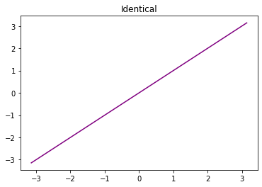

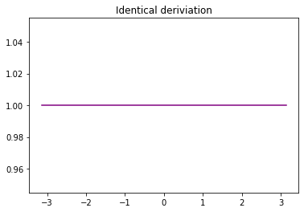

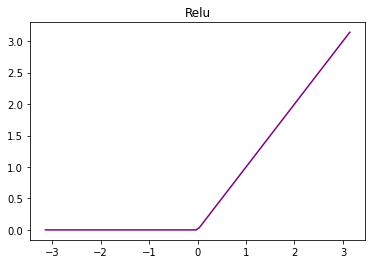

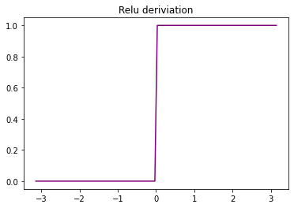

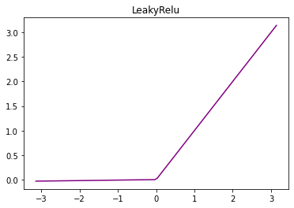

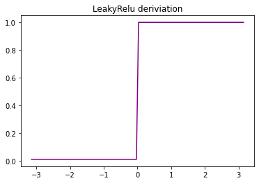

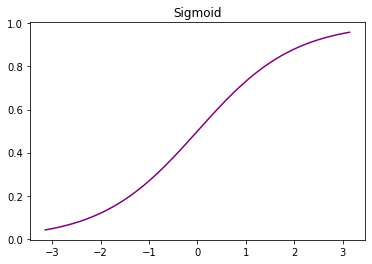

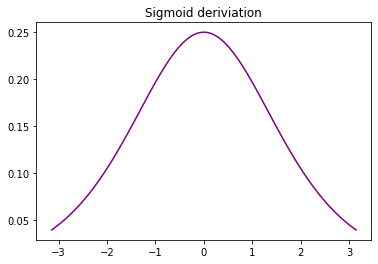

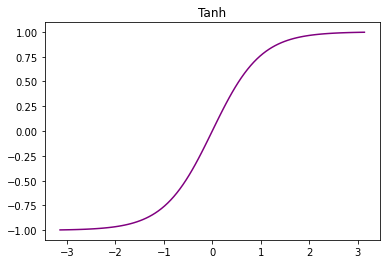

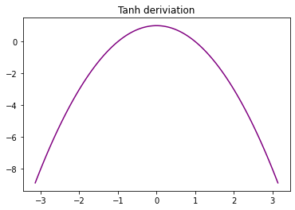

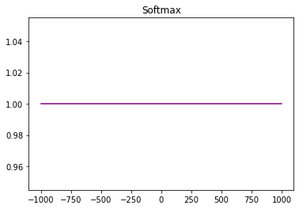

```python
def testFunctions(function, functionType):
    test = np.linspace(-np.pi, np.pi, 100)
    ans = function(test)
    plt.plot(test, ans, color = 'purple')
    plt.title(functionType)
    plt.show()
    ans = function.derivative(test)
    plt.plot(test, ans, color = 'purple')
    plt.title(functionType + ' deriviation')
    plt.show()

testFunctions(Identical(), "Identical")
testFunctions(Relu(), "Relu")
testFunctions(LeakyRelu(), "LeakyRelu")
testFunctions(Sigmoid(), "Sigmoid")
testFunctions(Tanh(), "Tanh")

test = np.linspace(-1000, 1000, 100)
softmax = Softmax()
ans = softmax(test)
plt.plot(test, ans, color = 'purple')
plt.title("Softmax")
plt.show()
```

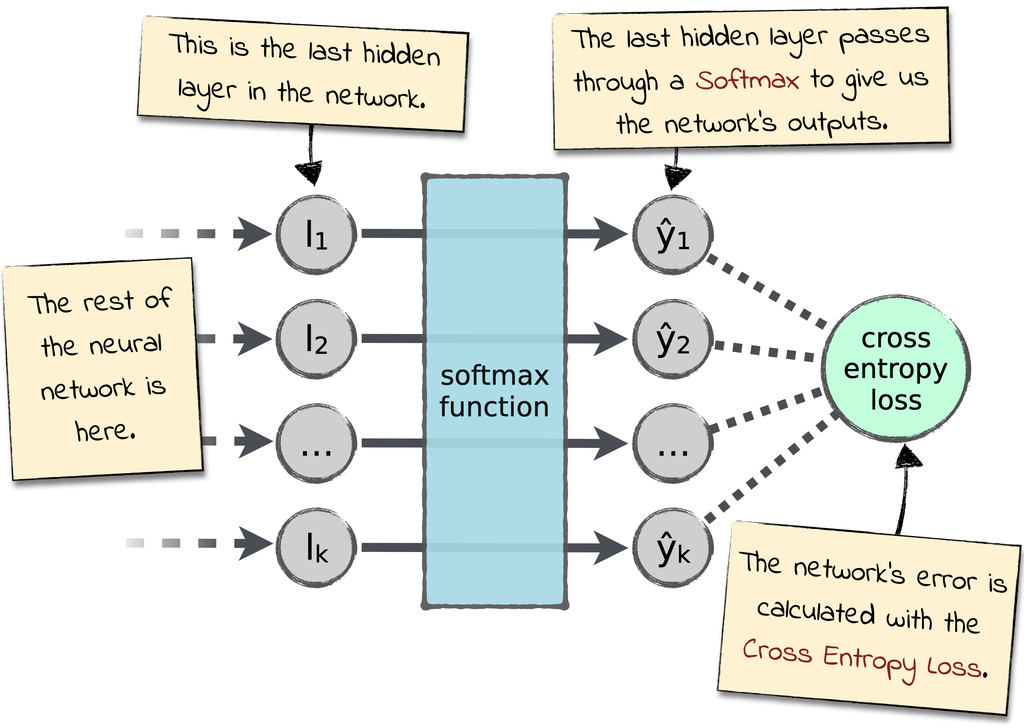

# Loss Function

```python
class CrossEntropy: #(with softmax)
    '''
    Cross-entropy is a measure of the difference between two probability
    distributions for a given random variable or set of events. You might
    recall that information quantifies the number of bits required to encode
    and transmit an event.
    The above image can help you.
    '''

    def __init__(self):
        pass
        '''
        This is the constructor. It does not have any fields
        as a result, there is no need to do anything in the constructor.
        '''

    def __val(self, true_val, expected_val):
        '''
        L(y^, y) = - Σ (y^(k)log (y^)^(k)) for k in K
        Parameters:
            true_val: calculated values (generated by neural network)
            expected_val: real values in dataset
        Returns:
            cross_entropy_value: cross entropy of inputs
        '''
        assert np.shape(true_val)==np.shape(expected_val)
        # TODO: Implement
        softmax = Softmax()
        logSoft = np.log(np.clip(softmax(true_val), 1e-50, 1 - 1e-50))
        cross_entropy_value = np.multiply(-expected_val, logSoft).sum(axis = 1)
        return cross_entropy_value

    def derivative(self, true_val, expected_val):
        '''
        Returns derivation of cross entropy.
            Parameters:
                true_val: calculated values (generated by neural network)
                expected_val: real values in dataset
            Returns:
                cross_entropy_derivative: cross entropy derivation of inputs
        '''
        assert np.shape(true_val)==np.shape(expected_val)
        # TODO: Implement
        softmax = Softmax()
        cross_entropy_derivative = softmax(true_val + 1e-50) - expected_val
        return cross_entropy_derivative

    def __call__(self, true_val, expected_val):
        '''
        __call__ is a special function in Python that, when implemented inside a class,
        gives its instances (objects) the ability to behave like a function.
        Here we return the _val method output.

            Parameters:
                true_val: calculated values (generated by neural network)
                expected_val: real values in dataset
            Returns:
                __val(matrix): __val return value for the input matrix
        '''
        return self.__val(true_val, expected_val)
```

# Layer

```python
class Layer:
    '''
    The layer class is used to define neural network layers.
    It stores all needed information for each layer, such as neurons count,
    weight matrix, bias, the output after applying the activation function, etc.
    '''

    DEFAULT_LOW, DEFAULT_HIGH, DEFAULT_MEAN, DEFAULT_VAR = 0, 0.05, 0., 1.

    def __init__(self, input_size, output_size, activation=Identical(), initial_weight='uniform',
                 **initializing_parameters):
        '''
        Parameters:
            input_size: the size of the input of this layer.
            output_size: the size of the output after this layer.
            activation: the activation function. It can be initialized to either of the previously defined activation classes.
                               default is an Identical activation function.
            initial_weight: either normal or uniform. It defines the method for weight initialization.
        '''

        assert type(initial_weight)==str, 'Undefined activation function!'

        self.__weight_initializer_dict = {'uniform':self.__uniform_weight, 'normal':self.__normal_weight}

        assert initial_weight in self.__weight_initializer_dict, 'Undefined weight initialization function!'


        self.__n_neurons = output_size
        weight_initializer = self.__weight_initializer_dict[initial_weight]
        self.__weight = weight_initializer(input_size, self.__n_neurons, **initializing_parameters)
        self.__bias = weight_initializer(1, self.__n_neurons, **initializing_parameters)
        self.__activation = activation

        self.__last_input = None
        self.__last_activation_input = None
        self.__last_activation_output = None
        self.__last_activation_derivative = None

    def forward(self, layer_input):
        '''
        It calculates the output of this layer for the layer_input argument.
        This method also stores __last_input, __last_activation_input, and __last_activation_derivative
        for future use in backpropagation.
        Parameters:
            layer_input: 2d np.matrix representing the input matrix of this layer.
        Returns:
            Final output of this layer after applying the activation function.
        '''
        assert np.ndim(layer_input)==2
        assert np.size(self.__weight,0) == np.size(layer_input,1)
        # TODO: Implement
        self.__last_input = layer_input
        self.__last_activation_input =  layer_input @ self.weight + self.bias
        self.__last_activation_output = self.activation(self.__last_activation_input)
        self.__last_activation_derivative = np.squeeze(self.activation.derivative(self.__last_activation_input))
        return self.__last_activation_output

    def update_weights(self, backprop_tensor, lr):
        '''
        It updates Layer weights according to the backpropagation matrix and learning rate.
        This method updates bias values as well.
        Parameters:
            backprop_tensor: 2d np.matrix passed from the next layer containing gradient values.
            lr: learning rate
        Returns:
            backprop_tensor to be used by the previous layer.
        '''
        assert np.ndim(backprop_tensor)==2
        assert np.size(backprop_tensor,0) == np.size(self.__last_activation_derivative,0)
        assert np.size(backprop_tensor,1) == self.__n_neurons
        # TODO: Implement
        yMat = np.multiply(backprop_tensor, self.__last_activation_derivative)
        backprop_tensor = np.matmul(yMat, self.__weight.transpose())
        self.__weight -= np.matmul(self.__last_input.transpose(), yMat) * lr
        self.__bias -= np.matmul(np.matrix(np.tile(1, (1, yMat.shape[0]))), yMat) * lr
        return backprop_tensor

    def __uniform_weight(self, dim1, dim2, **initializing_parameters):
        '''
        Initializes weights as a uniform distribution between low and high values.
        It uses default low and high values unless low or high are passed in initializing_parameters.
        Parameters:
            dim1: the size of the first dimension of weights.
            dim2: the size of the second dimension of weights.
            initializing_parameters: other initializing parameters; it can include custom low or high values.
        Returns:
            np.matrix with size (dim1, dim2) initialized using uniformly distributed values.
        '''
        low, high = self.DEFAULT_LOW, self.DEFAULT_HIGH
        if 'low' in initializing_parameters.keys(): low = initializing_parameters['low']
        if 'high' in initializing_parameters.keys(): high = initializing_parameters['high']
        # TODO: Implement
        weights = np.random.uniform(low = low, high = high, size = (dim1, dim2))
        return weights

    def __normal_weight(self, dim1, dim2, **initializing_parameters):
        '''
        Initializes weights as a normal distribution with mean and var values.
        It uses default mean and variance values unless mean or var are passed in initializing_parameters.
        Parameters:
            dim1: the size of the first dimension of weights.
            dim2: the size of the second dimension of weights.
            initializing_parameters: other initializing parameters; it can include custom mean or var values.
        Returns:
            np.matrix with size (dim1, dim2) initialized using normaly distributed values.
        '''
        mean, var = self.DEFAULT_MEAN, self.DEFAULT_VAR
        if 'mean' in initializing_parameters.keys(): mean = initializing_parameters['mean']
        if 'var' in initializing_parameters.keys(): var = initializing_parameters['var']
        # TODO: Implement
        weights = np.random.normal(loc = mean, scale = math.sqrt(var), size = (dim1, dim2))
        return weights

    @property
    def n_neurons(self): return self.__n_neurons

    @property
    def weight(self): return self.__weight

    @property
    def bias(self): return self.__bias

    @property
    def activation(self): return self.__activation
```

# Feed Forward Neural Network

```python
class FeedForwardNN:
    '''
    This class is used in order to implement custom feed-forward neural networks.
    The FeedForwardNN class stores a list of layers that determines all network layers.
    It also consists of the learning rate and loss function.
    '''
    def __init__(self, input_shape):
        '''
        Parameters:
            input_shape: the size of the first input to our neural network.
        '''

        self.__input_shape = input_shape
        self.__output_shape = None

        self.__layers_list = []

        self.__lr = None
        self.__loss = None


    def add_layer(self, n_neurons, activation=Relu(), initial_weight='uniform', **initializing_parameters):
        '''
         This method adds a new custom layer to the layers_list.
         Parameters:
             n_neurons: number of neurons in this layer
             activation: the activation function of this layer, default is Relu
             initial_weight: either a uniform or normal, default is uniform
             initializing_parameters: other initializing parameters such as low, high, mean, var, etc
        '''

        assert type(n_neurons)==int, "Invalid number of neurons for the layer!"
        assert n_neurons>0, "Invalid number of neurons for the layer!"

        n_prev_neurons = self.__input_shape if len(self.__layers_list)==0 else self.__layers_list[-1].n_neurons
        new_layer = Layer(n_prev_neurons, n_neurons, activation, initial_weight, **initializing_parameters)
        self.__layers_list.append(new_layer)
        self.__output_shape = self.__layers_list[-1].n_neurons


    def set_training_param(self, loss=CrossEntropy(), lr=1e-3):
        '''
        This method is used to set training parameters.
        Parameters:
            loss: loss function, default is CrossEntropy
            lr: learning rate, default is 1e-3
        '''
        assert self.__layers_list, "Uncomplete model!"
        self.__loss = loss
        self.__lr = lr


    def forward(self, network_input):
        '''
        This method calculates the output of the complete neural network for a passed input.
        Parameters:
            network_input: input of the neural network
        Returns:
            network_output: output of the neural network after forwarding the network_input
        '''
        assert type(self.__output_shape) != None, "Model is not compiled!"
        # TODO: Implement
        network_output = deepcopy(network_input)
        for layer in self.__layers_list:
            network_output = layer.forward(network_output)
            network_output = np.squeeze(network_output)
        return network_output


    def fit(self, epochs, trainloader, testloader=None, print_results=True):
        '''
        This method trains the neural network using specified parameters.
        It runs the __train private method epoch times and fills the log dictionary.
        Parameters:
            epochs: number of epochs to run
            trainloader: DataLoader for train data
            testloader: DataLoader for test data
            print_results: whether or not to print the results
        Returns:
            log: complete log of the training process as a dictionary consisting of
            train_accuracy, train_loss, test_accuracy, test_loss
        '''

        assert type(self.__output_shape) != None, "Model is not compiled!"
        assert type(self.__lr) != None and type(self.__loss) != None, "Training paramenters are not set!"

        log = {"train_accuracy":[], "train_loss":[], "test_accuracy":[], "test_loss":[]}

        for epoch in range(1, epochs+1):

            if print_results:
                print('Epoch {}:'.format(epoch))

            average_accuracy, average_loss = self.__train(trainloader)
            log['train_accuracy'].append(average_accuracy)
            log['train_loss'].append(average_loss)
            if print_results:
                print('\tTrain: Average Accuracy: {}\tAverage Loss: {}'.format(average_accuracy, average_loss))

            if type(testloader) != type(None):
                average_accuracy, average_loss = self.__test(testloader)
                log['test_accuracy'].append(average_accuracy)
                log['test_loss'].append(average_loss)
                if print_results:
                    print('\tTest: Average Accuracy: {}\tAverage Loss: {}'.format(average_accuracy, average_loss))

        return log


    def __train(self, trainloader):
        '''
        Trains the neural network for one epoch.
        Parameters:
            trainloader: A DataLoader consisting of train data
        Returns:
            batch_accuracy, batch_loss: mean of all batch_accuracies, batch_losses
        '''
#         print(trainloader)
        bach_accuracies, batch_losses = [], []
        for x_train, y_train in trainloader:
#             print("hello    ", y_train)
            batch_accuracy, batch_loss = self.__train_on_batch(x_train, y_train)
            bach_accuracies.append(batch_accuracy)
            batch_losses.append(batch_loss)
        return np.mean(bach_accuracies), np.mean(batch_losses)


    def __test(self, testloader):
        '''
        Test the neural network using a testloader.
        Parameters:
            testloader: A DataLoader of test data
        Returns:
            batch_accuracy, batch_loss: mean of all batch_accuracies, batch_losses
        '''
        bach_accuracies, batch_losses = [], []
        for x_test, y_test in testloader:
            batch_accuracy, batch_loss = self.__test_on_batch(x_test, y_test)
            bach_accuracies.append(batch_accuracy)
            batch_losses.append(batch_loss)
        return np.mean(bach_accuracies), np.mean(batch_losses)


    def __train_on_batch(self, x_batch, y_batch):
        '''
        Trains the neural network for one batch of train data.
        Parameters:
            x_batch: one batch data
            y_batch: labels for one batch
        Returns:
            (batch_accuracy, batch_average_loss)
        '''
        # TODO: Implement
        output_batch = self.forward(x_batch)
        batch_accuracy = self.__compute_accuracy(output_batch, y_batch)
        batch_average_loss = self.__update_weights(output_batch, y_batch)
        return (batch_accuracy, batch_average_loss)


    def __test_on_batch(self, x_batch, y_batch):
        '''
        Tests the neural network for one batch of test data.
        Parameters:
            x_batch: one batch data
            y_batch: labels for one batch
        Returns:
            (batch_accuracy, batch_average_loss)
        '''
        # TODO: Implement
        output_batch = self.forward(x_batch)
        cross_entropy = CrossEntropy()
        batch_average_loss = np.sum(cross_entropy(output_batch, y_batch)) / len(output_batch)
        batch_accuracy = self.__compute_accuracy(output_batch, y_batch)
        return (batch_accuracy, batch_average_loss)


    def __get_labels(self, outputs):
        '''
        Parameters:
            outputs: output of the neural network
        Returns:
            labels: labels generated from the outputs of the neural network
        '''
        # TODO: Implement
        labels = np.argmax(outputs, axis = 1)
        return labels


    def __compute_accuracy(self, output, expected_output):
        '''
        Computes accuracy by comparing output and expected_output.
        Parameters:
            output: actual output of the neural network
            expected_output: expected output
        Returns:
            accuracy
        '''
        # TODO: Implement
        labels = self.__get_labels(output)
        correctsCount = 0
        for i in range(len(output)):
            if (expected_output[i, labels[i]] == 1):
                correctsCount += 1
        accuracy = correctsCount / len(output)
        return accuracy


    def __update_weights(self, output, y_train):
        '''
        Updates weights of all layers according to neural network output and labels.
        Parameters:
            output: output of the neural network
            y_train: y labels for one batch of train data
        Returns:
            None
        '''
        # TODO: Implement
        crossEntropy = CrossEntropy()
        entrpDer = crossEntropy.derivative(output, y_train)
        for layer in reversed(self.__layers_list):
             entrpDer = layer.update_weights(entrpDer, self.__lr)
        return np.sum(crossEntropy(output, y_train)) / len(output)
```

# Part 3: Classifying data

# Section 1: Training network

```python
# Sample code for building and training a model

INPUT_SHAPE = 1024
LEARNING_RATE = 0.001
EPOCHS = 25
BATCH_SIZE = 32

TRAINLOADER = Dataloader(data = trainImagesDf.values.tolist(), labels = trainLabels['label'].values.tolist(),
                         n_classes = 2, batch_size = BATCH_SIZE, shuffle = False)
TESTLOADER = Dataloader(data = testImagesDf.values.tolist(), labels = testLabels['label'].values.tolist(),
                        n_classes = 2, batch_size = BATCH_SIZE, shuffle = False)

network = FeedForwardNN(INPUT_SHAPE)
network.add_layer(n_neurons = 4, activation = Relu(), weight_initializer = 'uniform')
network.add_layer(n_neurons = 4, activation = Relu(), weight_initializer = 'uniform')
network.add_layer(n_neurons = 2, activation = Identical(), weight_initializer = 'uniform')
network.set_training_param(loss = CrossEntropy(), lr = LEARNING_RATE)

log = network.fit(EPOCHS, TRAINLOADER, TESTLOADER)
```

```
Epoch 1:
	Train: Average Accuracy: 0.5059039087947883	Average Loss: 0.6935490339984016
	Test: Average Accuracy: 0.5267857142857143	Average Loss: 0.6921228392668741
Epoch 2:
	Train: Average Accuracy: 0.5090594462540716	Average Loss: 0.6932234070154542
	Test: Average Accuracy: 0.5267857142857143	Average Loss: 0.6920179336317954
Epoch 3:
	Train: Average Accuracy: 0.5108916938110749	Average Loss: 0.6931933532024583
	Test: Average Accuracy: 0.5044642857142857	Average Loss: 0.6919746899885357
Epoch 4:
	Train: Average Accuracy: 0.5139454397394136	Average Loss: 0.6931501161962463
	Test: Average Accuracy: 0.4732142857142857	Average Loss: 0.69196393650988
Epoch 5:
	Train: Average Accuracy: 0.5143526058631922	Average Loss: 0.6930769884789919
	Test: Average Accuracy: 0.45535714285714285	Average Loss: 0.6919667951653923
Epoch 6:
	Train: Average Accuracy: 0.5154723127035831	Average Loss: 0.6929473483174573
	Test: Average Accuracy: 0.46875	Average Loss: 0.6919664664285766
Epoch 7:
	Train: Average Accuracy: 0.5186278501628665	Average Loss: 0.6927035892266123
	Test: Average Accuracy: 0.48660714285714285	Average Loss: 0.6919356496632553
Epoch 8:
	Train: Average Accuracy: 0.5289087947882736	Average Loss: 0.692192244919095
	Test: Average Accuracy: 0.5178571428571429	Average Loss: 0.6917943398648735
Epoch 9:
	Train: Average Accuracy: 0.5392915309446255	Average Loss: 0.6908771098529014
	Test: Average Accuracy: 0.5625	Average Loss: 0.6910985816350229
Epoch 10:
	Train: Average Accuracy: 0.5554763843648208	Average Loss: 0.6865924354804642
	Test: Average Accuracy: 0.5625	Average Loss: 0.6879985331380114
Epoch 11:
	Train: Average Accuracy: 0.5733916938110749	Average Loss: 0.678577760666901
	Test: Average Accuracy: 0.5580357142857143	Average Loss: 0.6891569878025352
Epoch 12:
	Train: Average Accuracy: 0.5893729641693811	Average Loss: 0.6706842462553891
	Test: Average Accuracy: 0.5625	Average Loss: 0.6850479046240742
Epoch 13:
	Train: Average Accuracy: 0.6036237785016286	Average Loss: 0.6623395592381454
	Test: Average Accuracy: 0.5669642857142857	Average Loss: 0.6785089204311703
Epoch 14:
```

[output cut: 20 more lines]

```
Epoch 21:
	Train: Average Accuracy: 0.6466815960912052	Average Loss: 0.6288637242762403
	Test: Average Accuracy: 0.6294642857142857	Average Loss: 0.6562379551350845
Epoch 22:
	Train: Average Accuracy: 0.6459690553745928	Average Loss: 0.627806508687485
	Test: Average Accuracy: 0.6383928571428571	Average Loss: 0.6556144632388191
Epoch 23:
	Train: Average Accuracy: 0.6479030944625407	Average Loss: 0.626597912450234
	Test: Average Accuracy: 0.6294642857142857	Average Loss: 0.6546793193608937
Epoch 24:
	Train: Average Accuracy: 0.6519747557003257	Average Loss: 0.6254147220234594
	Test: Average Accuracy: 0.6339285714285714	Average Loss: 0.6545678608872085
Epoch 25:
	Train: Average Accuracy: 0.6518729641693811	Average Loss: 0.6246321380944097
	Test: Average Accuracy: 0.6339285714285714	Average Loss: 0.6539788989606163
```

# Section 2: Weighting the network

Neurons will get same features in each iterations because the derivatives wont change due to zero values of weights (even equal values for weights will cause this too).

# Section 3: Learning rate impact

```python
lrRange = np.linspace(0, 1, 20)
print(lrRange)
bestLr = [lrRange[0], 0.50]
EPOCHS = 3

for i in lrRange:
    network.set_training_param(loss = CrossEntropy(), lr = i)
    log = network.fit(EPOCHS, TRAINLOADER, TESTLOADER, print_results = False)
    if max(log['test_accuracy']) > bestLr[1]:
        bestLr = [i, max(log['test_accuracy'])]

print(bestLr)
```

```
[0.         0.05263158 0.10526316 0.15789474 0.21052632 0.26315789
 0.31578947 0.36842105 0.42105263 0.47368421 0.52631579 0.57894737
 0.63157895 0.68421053 0.73684211 0.78947368 0.84210526 0.89473684
 0.94736842 1.        ]
[0.0, 0.6339285714285714]
```

**Ten times smaller learning rate** As we can see small values for learning rate will cause stucking in a particular values and features vectors wont change that much.

```python
# Sample code for building and training a model

INPUT_SHAPE = 1024
LEARNING_RATE = 0.0001
EPOCHS = 25
BATCH_SIZE = 32

TRAINLOADER = Dataloader(data = trainImagesDf.values.tolist(), labels = trainLabels['label'].values.tolist(),
                         n_classes = 2, batch_size = BATCH_SIZE, shuffle = False)
TESTLOADER = Dataloader(data = testImagesDf.values.tolist(), labels = testLabels['label'].values.tolist(),
                        n_classes = 2, batch_size = BATCH_SIZE, shuffle = False)

network = FeedForwardNN(INPUT_SHAPE)
network.add_layer(n_neurons = 4, activation = LeakyRelu(), weight_initializer = 'uniform')
network.add_layer(n_neurons = 4, activation = LeakyRelu(), weight_initializer = 'uniform')
network.add_layer(n_neurons = 2, activation = Identical(), weight_initializer = 'uniform')
network.set_training_param(loss = CrossEntropy(), lr = LEARNING_RATE)

log = network.fit(EPOCHS, TRAINLOADER, TESTLOADER)
```

```
Epoch 1:
	Train: Average Accuracy: 0.5	Average Loss: 0.6932826376824316
	Test: Average Accuracy: 0.4732142857142857	Average Loss: 0.693449561915944
Epoch 2:
	Train: Average Accuracy: 0.49949104234527686	Average Loss: 0.693178358920036
	Test: Average Accuracy: 0.4955357142857143	Average Loss: 0.6934054741681895
Epoch 3:
	Train: Average Accuracy: 0.5022394136807817	Average Loss: 0.6930735850325929
	Test: Average Accuracy: 0.5178571428571429	Average Loss: 0.6933799727904423
Epoch 4:
	Train: Average Accuracy: 0.5117060260586319	Average Loss: 0.692974075102616
	Test: Average Accuracy: 0.5089285714285714	Average Loss: 0.6933560625534583
Epoch 5:
	Train: Average Accuracy: 0.5228013029315961	Average Loss: 0.6928797704340227
	Test: Average Accuracy: 0.53125	Average Loss: 0.693333164216959
Epoch 6:
	Train: Average Accuracy: 0.5324714983713354	Average Loss: 0.6927902193595742
	Test: Average Accuracy: 0.5267857142857143	Average Loss: 0.6933111791595856
Epoch 7:
	Train: Average Accuracy: 0.5373574918566775	Average Loss: 0.6927049955316129
	Test: Average Accuracy: 0.5401785714285714	Average Loss: 0.6932900562303617
Epoch 8:
	Train: Average Accuracy: 0.5445846905537459	Average Loss: 0.6926237102217957
	Test: Average Accuracy: 0.5401785714285714	Average Loss: 0.6932697725420722
Epoch 9:
	Train: Average Accuracy: 0.5497760586319218	Average Loss: 0.6925460124133551
	Test: Average Accuracy: 0.5357142857142857	Average Loss: 0.6932503270658847
Epoch 10:
	Train: Average Accuracy: 0.5499796416938111	Average Loss: 0.6924715873164994
	Test: Average Accuracy: 0.5357142857142857	Average Loss: 0.6932317352616935
Epoch 11:
	Train: Average Accuracy: 0.5507939739413681	Average Loss: 0.6924001538551396
	Test: Average Accuracy: 0.5357142857142857	Average Loss: 0.6932140241184506
Epoch 12:
	Train: Average Accuracy: 0.5515065146579805	Average Loss: 0.6923314614824567
	Test: Average Accuracy: 0.5357142857142857	Average Loss: 0.6931972275468903
Epoch 13:
	Train: Average Accuracy: 0.5529315960912052	Average Loss: 0.692265286676929
	Test: Average Accuracy: 0.53125	Average Loss: 0.6931813822339313
Epoch 14:
```

[output cut: 20 more lines]

```
Epoch 21:
	Train: Average Accuracy: 0.551099348534202	Average Loss: 0.6918060622454939
	Test: Average Accuracy: 0.5089285714285714	Average Loss: 0.6930920524596154
Epoch 22:
	Train: Average Accuracy: 0.5507939739413681	Average Loss: 0.6917554175139539
	Test: Average Accuracy: 0.5133928571428571	Average Loss: 0.6930856883763379
Epoch 23:
	Train: Average Accuracy: 0.5516083061889251	Average Loss: 0.6917059079436305
	Test: Average Accuracy: 0.53125	Average Loss: 0.6930803540013244
Epoch 24:
	Train: Average Accuracy: 0.5523208469055375	Average Loss: 0.6916574395725847
	Test: Average Accuracy: 0.53125	Average Loss: 0.6930760217543277
Epoch 25:
	Train: Average Accuracy: 0.5515065146579805	Average Loss: 0.6916099222848022
	Test: Average Accuracy: 0.53125	Average Loss: 0.6930726598257693
```

**Ten times bigger learning rate**

```python
# Sample code for building and training a model

INPUT_SHAPE = 1024
LEARNING_RATE = 0.01
EPOCHS = 25
BATCH_SIZE = 32

TRAINLOADER = Dataloader(data = trainImagesDf.values.tolist(), labels = trainLabels['label'].values.tolist(),
                         n_classes = 2, batch_size = BATCH_SIZE, shuffle = False)
TESTLOADER = Dataloader(data = testImagesDf.values.tolist(), labels = testLabels['label'].values.tolist(),
                        n_classes = 2, batch_size = BATCH_SIZE, shuffle = False)

network = FeedForwardNN(INPUT_SHAPE)
network.add_layer(n_neurons = 4, activation = LeakyRelu(), weight_initializer = 'uniform')
network.add_layer(n_neurons = 4, activation = LeakyRelu(), weight_initializer = 'uniform')
network.add_layer(n_neurons = 2, activation = Identical(), weight_initializer = 'uniform')
network.set_training_param(loss = CrossEntropy(), lr = LEARNING_RATE)

log = network.fit(EPOCHS, TRAINLOADER, TESTLOADER)
```

```
Epoch 1:
	Train: Average Accuracy: 0.48900651465798045	Average Loss: 0.6950901695655821
	Test: Average Accuracy: 0.5267857142857143	Average Loss: 0.6918337457675758
Epoch 2:
	Train: Average Accuracy: 0.48778501628664495	Average Loss: 0.6950223580038724
	Test: Average Accuracy: 0.5267857142857143	Average Loss: 0.6918318577044583
Epoch 3:
	Train: Average Accuracy: 0.4876832247557003	Average Loss: 0.6950074152867388
	Test: Average Accuracy: 0.5267857142857143	Average Loss: 0.6918289075052984
Epoch 4:
	Train: Average Accuracy: 0.4887011400651466	Average Loss: 0.6949826785695172
	Test: Average Accuracy: 0.5267857142857143	Average Loss: 0.6918239151342647
Epoch 5:
	Train: Average Accuracy: 0.4887011400651466	Average Loss: 0.6949393453662648
	Test: Average Accuracy: 0.5267857142857143	Average Loss: 0.6918150529842031
Epoch 6:
	Train: Average Accuracy: 0.49144951140065146	Average Loss: 0.6948608676547202
	Test: Average Accuracy: 0.5267857142857143	Average Loss: 0.6917989138072672
Epoch 7:
	Train: Average Accuracy: 0.49297638436482083	Average Loss: 0.6947142761624822
	Test: Average Accuracy: 0.5267857142857143	Average Loss: 0.6917690532876591
Epoch 8:
	Train: Average Accuracy: 0.4960301302931596	Average Loss: 0.6944300597566645
	Test: Average Accuracy: 0.5267857142857143	Average Loss: 0.6917147667681071
Epoch 9:
	Train: Average Accuracy: 0.5026465798045603	Average Loss: 0.6938597446145469
	Test: Average Accuracy: 0.4732142857142857	Average Loss: 0.6916299660654907
Epoch 10:
	Train: Average Accuracy: 0.5151669381107492	Average Loss: 0.6927174203908024
	Test: Average Accuracy: 0.47767857142857145	Average Loss: 0.6915757024935937
Epoch 11:
	Train: Average Accuracy: 0.5386807817589576	Average Loss: 0.6906294289409131
	Test: Average Accuracy: 0.5267857142857143	Average Loss: 0.6917887125653526
Epoch 12:
	Train: Average Accuracy: 0.5528298045602605	Average Loss: 0.68736952624673
	Test: Average Accuracy: 0.5044642857142857	Average Loss: 0.6917587469718531
Epoch 13:
	Train: Average Accuracy: 0.5688110749185668	Average Loss: 0.6828452724821581
	Test: Average Accuracy: 0.5535714285714286	Average Loss: 0.6923863626896765
Epoch 14:
```

[output cut: 20 more lines]

```
Epoch 21:
	Train: Average Accuracy: 0.6466815960912052	Average Loss: 0.6200622349478263
	Test: Average Accuracy: 0.6160714285714286	Average Loss: 0.6781257897847731
Epoch 22:
	Train: Average Accuracy: 0.6556392508143323	Average Loss: 0.6115858006733278
	Test: Average Accuracy: 0.5669642857142857	Average Loss: 0.6561818284874624
Epoch 23:
	Train: Average Accuracy: 0.6654112377850163	Average Loss: 0.6047191387534784
	Test: Average Accuracy: 0.6071428571428571	Average Loss: 0.6654129619265158
Epoch 24:
	Train: Average Accuracy: 0.6733509771986971	Average Loss: 0.5962460023579954
	Test: Average Accuracy: 0.625	Average Loss: 0.661655912553004
Epoch 25:
	Train: Average Accuracy: 0.6731473941368078	Average Loss: 0.5896553487451527
	Test: Average Accuracy: 0.65625	Average Loss: 0.6495550420110742
```

# Section 4: Activation function impact

```python
# Sample code for building and training a model

INPUT_SHAPE = 1024
LEARNING_RATE = 0.01
EPOCHS = 25
BATCH_SIZE = 32
TRAINLOADER = Dataloader(data = trainImagesDf.values.tolist(), labels = trainLabels['label'].values.tolist(),
                         n_classes = 2, batch_size = BATCH_SIZE, shuffle = False)
TESTLOADER = Dataloader(data = testImagesDf.values.tolist(), labels = testLabels['label'].values.tolist(),
                        n_classes = 2, batch_size = BATCH_SIZE, shuffle = False)
```

# Sigmoid:

```python
network = FeedForwardNN(INPUT_SHAPE)
network.add_layer(n_neurons = 16, activation = Sigmoid(), weight_initializer = 'uniform')
network.add_layer(n_neurons = 16, activation = Sigmoid(), weight_initializer = 'uniform')
network.add_layer(n_neurons = 2, activation = Identical(), weight_initializer = 'uniform')
network.set_training_param(loss = CrossEntropy(), lr = LEARNING_RATE)

log = network.fit(EPOCHS, TRAINLOADER, TESTLOADER, print_results = False)
print('Max train accuracy: ', max(log['train_accuracy']))
print('Max train loss: ', max(log['train_loss']))
print('Max test accuracy: ', max(log['test_accuracy']))
print('Max test loss: ', max(log['test_loss']))
```

```
Max train accuracy:  0.4955211726384365
Max train loss:  0.7049519824501899
Max test accuracy:  0.5267857142857143
Max test loss:  0.6919513757304697
```

As we can see sigmoid function is not good because the derivative of the sigmoid is small (less than 0.25) and when we have several layers this small value of the derivative of the sigmoid will cause the values less than 1 to go to zero quickly.

# Tanh:

```python
network = FeedForwardNN(INPUT_SHAPE)
network.add_layer(n_neurons = 16, activation = Tanh(), weight_initializer = 'uniform')
network.add_layer(n_neurons = 16, activation = Tanh(), weight_initializer = 'uniform')
network.add_layer(n_neurons = 2, activation = Identical(), weight_initializer = 'uniform')
network.set_training_param(loss = CrossEntropy(), lr = LEARNING_RATE)

log = network.fit(EPOCHS, TRAINLOADER, TESTLOADER, print_results = False)
print('Max train accuracy: ', max(log['train_accuracy']))
print('Max train loss: ', max(log['train_loss']))
print('Max test accuracy: ', max(log['test_accuracy']))
print('Max test loss: ', max(log['test_loss']))
```

```
Max train accuracy:  0.5
Max train loss:  nan
Max test accuracy:  0.5267857142857143
Max test loss:  nan
```

Tanh is not good too because it has more computation than sigmoid and also doesnt do well with gradient vanishing.

# Leaky ReLU:

```python
network = FeedForwardNN(INPUT_SHAPE)
network.add_layer(n_neurons = 16, activation = LeakyRelu(), weight_initializer = 'uniform')
network.add_layer(n_neurons = 16, activation = LeakyRelu(), weight_initializer = 'uniform')
network.add_layer(n_neurons = 2, activation = Identical(), weight_initializer = 'uniform')
network.set_training_param(loss = CrossEntropy(), lr = LEARNING_RATE)

log = network.fit(EPOCHS, TRAINLOADER, TESTLOADER, print_results = False)
print('Max train accuracy: ', max(log['train_accuracy']))
print('Max train loss: ', max(log['train_loss']))
print('Max test accuracy: ', max(log['test_accuracy']))
print('Max test loss: ', max(log['test_loss']))
```

```
Max train accuracy:  0.7177320846905537
Max train loss:  0.7969648314018852
Max test accuracy:  0.7008928571428571
Max test loss:  0.6771071290727387
```

Leaky ReLU doesnt return 0 for inputs less than 0 and give them a negetive value and also Using Leaky ReLU will speeds up training.

# Section 5: Batch size impact

**Batch size = 16**

```python
# Sample code for building and training a model

INPUT_SHAPE = 1024
LEARNING_RATE = 0.01
EPOCHS = 25
BATCH_SIZE = 16

TRAINLOADER = Dataloader(data = trainImagesDf.values.tolist(), labels = trainLabels['label'].values.tolist(),
                         n_classes = 2, batch_size = BATCH_SIZE, shuffle = False)
TESTLOADER = Dataloader(data = testImagesDf.values.tolist(), labels = testLabels['label'].values.tolist(),
                        n_classes = 2, batch_size = BATCH_SIZE, shuffle = False)

network = FeedForwardNN(INPUT_SHAPE)
network.add_layer(n_neurons = 16, activation = LeakyRelu(), weight_initializer = 'uniform')
network.add_layer(n_neurons = 16, activation = LeakyRelu(), weight_initializer = 'uniform')
network.add_layer(n_neurons = 2, activation = Identical(), weight_initializer = 'uniform')
network.set_training_param(loss = CrossEntropy(), lr = LEARNING_RATE)

log = network.fit(EPOCHS, TRAINLOADER, TESTLOADER)
```

```
Epoch 1:
	Train: Average Accuracy: 0.5039763458401305	Average Loss: 0.7247207562552531
	Test: Average Accuracy: 0.5048076923076923	Average Loss: 0.6949405471203479
Epoch 2:
	Train: Average Accuracy: 0.5351753670473083	Average Loss: 0.6934179631247948
	Test: Average Accuracy: 0.5432692307692307	Average Loss: 0.6964375725405746
Epoch 3:
	Train: Average Accuracy: 0.5767740619902121	Average Loss: 0.6810348651288642
	Test: Average Accuracy: 0.5288461538461539	Average Loss: 0.6911370368359419
Epoch 4:
	Train: Average Accuracy: 0.6081769983686787	Average Loss: 0.6613783958787341
	Test: Average Accuracy: 0.5576923076923077	Average Loss: 0.6786389343862183
Epoch 5:
	Train: Average Accuracy: 0.6177610114192496	Average Loss: 0.6512972632998957
	Test: Average Accuracy: 0.5673076923076923	Average Loss: 0.6721820453823923
Epoch 6:
	Train: Average Accuracy: 0.6352977161500816	Average Loss: 0.639898260709772
	Test: Average Accuracy: 0.5769230769230769	Average Loss: 0.6684895105244858
Epoch 7:
	Train: Average Accuracy: 0.6407014681892332	Average Loss: 0.6298734507817306
	Test: Average Accuracy: 0.6009615384615384	Average Loss: 0.6452271283516845
Epoch 8:
	Train: Average Accuracy: 0.6470228384991843	Average Loss: 0.6285820652277685
	Test: Average Accuracy: 0.5961538461538461	Average Loss: 0.6413802812120533
Epoch 9:
	Train: Average Accuracy: 0.6646615008156607	Average Loss: 0.610863537915904
	Test: Average Accuracy: 0.625	Average Loss: 0.6165563997484408
Epoch 10:
	Train: Average Accuracy: 0.6706769983686787	Average Loss: 0.5994396795346704
	Test: Average Accuracy: 0.6634615384615384	Average Loss: 0.5996594341321816
Epoch 11:
	Train: Average Accuracy: 0.6838295269168027	Average Loss: 0.5881892414540557
	Test: Average Accuracy: 0.6490384615384616	Average Loss: 0.6072694310523705
Epoch 12:
	Train: Average Accuracy: 0.6857667210440457	Average Loss: 0.5774094854363491
	Test: Average Accuracy: 0.6826923076923077	Average Loss: 0.5771677901911316
Epoch 13:
	Train: Average Accuracy: 0.695452691680261	Average Loss: 0.5677967453167114
	Test: Average Accuracy: 0.7067307692307693	Average Loss: 0.5639127708641938
Epoch 14:
```

[output cut: 20 more lines]

```
Epoch 21:
	Train: Average Accuracy: 0.7139070146818923	Average Loss: 0.5512624112858405
	Test: Average Accuracy: 0.7211538461538461	Average Loss: 0.5353412658845951
Epoch 22:
	Train: Average Accuracy: 0.7142128874388255	Average Loss: 0.553478499091679
	Test: Average Accuracy: 0.7067307692307693	Average Loss: 0.5559671889831941
Epoch 23:
	Train: Average Accuracy: 0.7191068515497553	Average Loss: 0.5424979563562459
	Test: Average Accuracy: 0.7403846153846154	Average Loss: 0.5557960695192949
Epoch 24:
	Train: Average Accuracy: 0.7334828711256117	Average Loss: 0.526289330825146
	Test: Average Accuracy: 0.7211538461538461	Average Loss: 0.5383145807462726
Epoch 25:
	Train: Average Accuracy: 0.7400081566068516	Average Loss: 0.5181514393288821
	Test: Average Accuracy: 0.7307692307692307	Average Loss: 0.5303193382516238
```

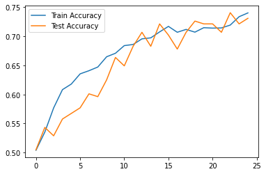

```python
trainAccuracyPlot, = plt.plot(log['train_accuracy'], label="Train Accuracy")
testAccuracyPlot, = plt.plot(log['test_accuracy'], label="Test Accuracy")
plt.legend(handles = [trainAccuracyPlot, testAccuracyPlot])
```

**Batch size = 256**

```python
# Sample code for building and training a model

INPUT_SHAPE = 1024
LEARNING_RATE = 0.001
EPOCHS = 25
BATCH_SIZE = 256

TRAINLOADER = Dataloader(data = trainImagesDf.values.tolist(), labels = trainLabels['label'].values.tolist(),
                         n_classes = 2, batch_size = BATCH_SIZE, shuffle = False)
TESTLOADER = Dataloader(data = testImagesDf.values.tolist(), labels = testLabels['label'].values.tolist(),
                        n_classes = 2, batch_size = BATCH_SIZE, shuffle = False)

network = FeedForwardNN(INPUT_SHAPE)
network.add_layer(n_neurons = 16, activation = LeakyRelu(), weight_initializer = 'uniform')
network.add_layer(n_neurons = 16, activation = LeakyRelu(), weight_initializer = 'uniform')
network.add_layer(n_neurons = 2, activation = Identical(), weight_initializer = 'uniform')
network.set_training_param(loss = CrossEntropy(), lr = LEARNING_RATE)

log = network.fit(EPOCHS, TRAINLOADER, TESTLOADER)
```

```
Epoch 1:
	Train: Average Accuracy: 0.5189191595441596	Average Loss: 1.166277664551821
	Test: Average Accuracy: 0.57	Average Loss: 0.6869948668410957
Epoch 2:
	Train: Average Accuracy: 0.5611088853276354	Average Loss: 0.6842817465626514
	Test: Average Accuracy: 0.55	Average Loss: 0.6825262607073033
Epoch 3:
	Train: Average Accuracy: 0.5872061965811967	Average Loss: 0.6744483919610812
	Test: Average Accuracy: 0.55	Average Loss: 0.6813852616368556
Epoch 4:
	Train: Average Accuracy: 0.6004829950142451	Average Loss: 0.6679147482920248
	Test: Average Accuracy: 0.555	Average Loss: 0.6811128622866878
Epoch 5:
	Train: Average Accuracy: 0.609508547008547	Average Loss: 0.663183110192107
	Test: Average Accuracy: 0.56	Average Loss: 0.6799211058782774
Epoch 6:
	Train: Average Accuracy: 0.6168870192307693	Average Loss: 0.6589126342777536
	Test: Average Accuracy: 0.58	Average Loss: 0.678086222404237
Epoch 7:
	Train: Average Accuracy: 0.6220953525641025	Average Loss: 0.6547232576763167
	Test: Average Accuracy: 0.57	Average Loss: 0.6759453125694218
Epoch 8:
	Train: Average Accuracy: 0.6263911146723646	Average Loss: 0.6510866647640164
	Test: Average Accuracy: 0.57	Average Loss: 0.6800040707940375
Epoch 9:
	Train: Average Accuracy: 0.6307536502849003	Average Loss: 0.6469324167837807
	Test: Average Accuracy: 0.585	Average Loss: 0.6713418019056899
Epoch 10:
	Train: Average Accuracy: 0.63455974002849	Average Loss: 0.6426682607545844
	Test: Average Accuracy: 0.59	Average Loss: 0.669131731330637
Epoch 11:
	Train: Average Accuracy: 0.6372195512820513	Average Loss: 0.6399527013541659
	Test: Average Accuracy: 0.595	Average Loss: 0.6670833515264833
Epoch 12:
	Train: Average Accuracy: 0.6385327635327636	Average Loss: 0.6350529237682495
	Test: Average Accuracy: 0.61	Average Loss: 0.6623000016083657
Epoch 13:
	Train: Average Accuracy: 0.6420272435897436	Average Loss: 0.6328626058893351
	Test: Average Accuracy: 0.605	Average Loss: 0.6499492970246061
Epoch 14:
```

[output cut: 20 more lines]

```
Epoch 21:
	Train: Average Accuracy: 0.6663327991452992	Average Loss: 0.6098698606175126
	Test: Average Accuracy: 0.63	Average Loss: 0.6193060952916646
Epoch 22:
	Train: Average Accuracy: 0.6679019764957265	Average Loss: 0.6050731834887041
	Test: Average Accuracy: 0.635	Average Loss: 0.6192304120342347
Epoch 23:
	Train: Average Accuracy: 0.6690705128205128	Average Loss: 0.5984655217967171
	Test: Average Accuracy: 0.67	Average Loss: 0.6099426686268753
Epoch 24:
	Train: Average Accuracy: 0.6729211182336182	Average Loss: 0.5970246557687894
	Test: Average Accuracy: 0.67	Average Loss: 0.5955184517030664
Epoch 25:
	Train: Average Accuracy: 0.6759704415954416	Average Loss: 0.5914107802419226
	Test: Average Accuracy: 0.675	Average Loss: 0.590993291114405
```

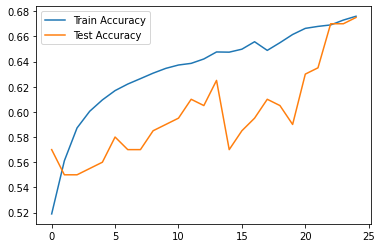

```python
trainAccuracyPlot, = plt.plot(log['train_accuracy'], label="Train Accuracy")
testAccuracyPlot, = plt.plot(log['test_accuracy'], label="Test Accuracy")
plt.legend(handles = [trainAccuracyPlot, testAccuracyPlot])
```

With smaller batch size we will have slower neural network because number of backward and forward propagations will increase. It will also cause higher variance because of smaller number of training samples.

**Reason of using batches** We use it because the overall training procedure requires less memory due to having fewer samples and its important if we cannot fit the whole dataset in our machine's memory.

# My own parameters:

```python
# Sample code for building and training a model

INPUT_SHAPE = 1024
LEARNING_RATE = 0.001
EPOCHS = 25
BATCH_SIZE = 256

TRAINLOADER = Dataloader(data = trainImagesDf.values.tolist(), labels = trainLabels['label'].values.tolist(),
                         n_classes = 2, batch_size = BATCH_SIZE, shuffle = False)
TESTLOADER = Dataloader(data = testImagesDf.values.tolist(), labels = testLabels['label'].values.tolist(),
                        n_classes = 2, batch_size = BATCH_SIZE, shuffle = False)

network = FeedForwardNN(INPUT_SHAPE)
network.add_layer(n_neurons = 16, activation = LeakyRelu(), weight_initializer = 'uniform')
network.add_layer(n_neurons = 16, activation = LeakyRelu(), weight_initializer = 'uniform')
network.add_layer(n_neurons = 2, activation = LeakyRelu(), weight_initializer = 'uniform')
network.set_training_param(loss = CrossEntropy(), lr = LEARNING_RATE)

log = network.fit(EPOCHS, TRAINLOADER, TESTLOADER)
```

```
Epoch 1:
	Train: Average Accuracy: 0.4882033475783476	Average Loss: 0.9998814842795672
	Test: Average Accuracy: 0.48	Average Loss: 0.6922296463141956
Epoch 2:
	Train: Average Accuracy: 0.48648949430199434	Average Loss: 0.6954321628026171
	Test: Average Accuracy: 0.515	Average Loss: 0.6924107505150934
Epoch 3:
	Train: Average Accuracy: 0.49846420940170943	Average Loss: 0.6941638518687198
	Test: Average Accuracy: 0.515	Average Loss: 0.692842332202722
Epoch 4:
	Train: Average Accuracy: 0.5112847222222222	Average Loss: 0.693359275761266
	Test: Average Accuracy: 0.515	Average Loss: 0.6933425090713876
Epoch 5:
	Train: Average Accuracy: 0.518596420940171	Average Loss: 0.6928100581267602
	Test: Average Accuracy: 0.485	Average Loss: 0.6938374397249764
Epoch 6:
	Train: Average Accuracy: 0.5254073183760684	Average Loss: 0.6923995093629111
	Test: Average Accuracy: 0.465	Average Loss: 0.6942891166390374
Epoch 7:
	Train: Average Accuracy: 0.5307714565527066	Average Loss: 0.6920534203983564
	Test: Average Accuracy: 0.45	Average Loss: 0.6946879088596225
Epoch 8:
	Train: Average Accuracy: 0.5322182158119658	Average Loss: 0.6917392202854595
	Test: Average Accuracy: 0.46	Average Loss: 0.6950408461443413
Epoch 9:
	Train: Average Accuracy: 0.5347222222222222	Average Loss: 0.6914297880632436
	Test: Average Accuracy: 0.45	Average Loss: 0.6953578098474006
Epoch 10:
	Train: Average Accuracy: 0.5362246260683761	Average Loss: 0.691116544338055
	Test: Average Accuracy: 0.455	Average Loss: 0.6956425037885728
Epoch 11:
	Train: Average Accuracy: 0.5394297542735043	Average Loss: 0.6907917507094176
	Test: Average Accuracy: 0.465	Average Loss: 0.6958963252561279
Epoch 12:
	Train: Average Accuracy: 0.5425347222222222	Average Loss: 0.6904471255698751
	Test: Average Accuracy: 0.46	Average Loss: 0.6961370693025211
Epoch 13:
	Train: Average Accuracy: 0.5431913283475784	Average Loss: 0.6900699569035517
	Test: Average Accuracy: 0.465	Average Loss: 0.6963631048781166
Epoch 14:
```

[output cut: 20 more lines]

```
Epoch 21:
	Train: Average Accuracy: 0.5599737357549858	Average Loss: 0.6856327006945021
	Test: Average Accuracy: 0.5	Average Loss: 0.6983455178282949
Epoch 22:
	Train: Average Accuracy: 0.5623887108262108	Average Loss: 0.6849200848026821
	Test: Average Accuracy: 0.5	Average Loss: 0.6985921612342523
Epoch 23:
	Train: Average Accuracy: 0.5653044871794872	Average Loss: 0.6841593241017119
	Test: Average Accuracy: 0.505	Average Loss: 0.6987872106255216
Epoch 24:
	Train: Average Accuracy: 0.5662059294871795	Average Loss: 0.6833755715014126
	Test: Average Accuracy: 0.505	Average Loss: 0.6989927164894758
Epoch 25:
	Train: Average Accuracy: 0.5680088141025641	Average Loss: 0.6825332782168123
	Test: Average Accuracy: 0.51	Average Loss: 0.6991955457131411
```